# Chapter 4. Linear time series models and the algebra of ARMA models

### Stationary causal linear process

A **stationary causal linear process** is a time series models that can be written as

$$Y_n = \mu + g_0\epsilon_n + g_1\epsilon_{n-1}+g_2\epsilon_{n-2}+g_3\epsilon_{n-3} + g_4\epsilon_{n-4}+\dots$$

where $\{\epsilon_n, n=\dots,-2,-1,0,1,2,\dots\}$ is a white noise process, defined for all integer timepoints, with variance $\operatorname{Var}(\epsilon_n)=\sigma^2$. It is also the MA$(\infty)$ model. We do not need to define any initial values. The **doubly infinite noise process** is enough to define $Y_n$ for every $n$ as long as the sequence in $Y_n$ converges. It is **stationary** since the construction is the same for each $n$.

If the white noise process is strict stationary, e.g., IID white noise, $Y_n$ is strict stationary. If only has constant mean and shift-invariant covariance, it is weak stationary.

#### Autocovariance function for a linear process

$$\gamma_h = \operatorname{Cov}(Y_n,Y_{n+h}) = \sum_{j=0}^\infty g_jg_{j+h} \sigma^2, \mbox{for $h\ge 0$}.$$

In order for this autocovariance function to exist, we need
$$\sum_{j=0}^\infty g_j^2 < \infty.$$

In the derivation, there is an assumption that move $\sum_{j=0}^\infty \sum_{k=0}^\infty$ through $\operatorname{Cov}$ is okay. The interchange of expectation and infinite sums can’t be taken for granted. $\operatorname{Cov}\left(\sum_{i=1}^m X_i,\sum_{j=1}^n Y_j\right)=\sum_{i=1}^m\sum_{j=1}^n\operatorname{Cov}(X_i,Y_j)$ is true for finite $m$ and $n$, but not necessarily for infinite sums.

### The backshift operator $B$ and the difference operator $\Delta$

The backshift operator B, also known as the lag operator,
$$B Y_n = Y_{n-1}$$
is a **linear operator**.

The difference operator $\Delta=1-B$ is
$$\Delta Y_n = (1-B)Y_n = Y_n - Y_{n-1}$$

Recall the AR$(p)$ model is defined as
$$Y_n = \phi_1Y_{n-1} + ... + \phi_pY_{n-p} + \epsilon_n.$$
Define an order $p$ polynomial $\phi(x)= 1-\phi_1 x -\phi_2 x^2 -\dots -\phi_p x^p$, we can rewrite AR$(p)$ model as
$$\phi(B) Y_n = \epsilon_n.$$

Recall the MA$(q)$ model is defined as
$$Y_n = \epsilon_n + \theta_1\epsilon_{n-1} + ... + \theta_q\epsilon_{n-q}.$$
Define an order $q$ polynomial $\psi(x) = 1+\psi_1 x +\psi_2 x^2 + \dots +\psi_q x^q$, the MA$(q)$ model is equivalent to
$$Y_n = \psi(B)\epsilon_n.$$

If $g(x)$ is a function defined by the Taylor series expansion
$$g(x)= g_0 + g_1 x + g_2 x^2 + g_3 x^3 + g_4 x^4 + \dots,$$
we can write the stationary causal linear process equation as $Y_n = \mu + g(B)\epsilon_n$.

### ARMA$(p,q)$

Put together AR and MA model, we have the **autoregressive moving average** ARMA$(p,q)$ model given by
$$Y_n = \phi_1 Y_{n-1}+\phi_2Y_{n-2}+\dots+\phi_pY_{n-p} + \epsilon_n +\psi_1 \epsilon_{n-1} +\dots+\psi_q\epsilon_{n-q},$$
where $\{ \epsilon_n\}$ is a white noise process. Using the backshift operator, we have
$$\phi(B)Y_n = \psi(B)\epsilon_n.$$
In general, if the mean of $Y_n$ is nonzero, the equation is
$$\phi(B)(Y_n-\mu) = \psi(B)\epsilon_n.$$

#### MA$(\infty)$ representation of ARMA model

We say that the ARMA model is **causal** if its MA$(\infty)$ representation is a convergent series.

#### Causality and invertibility

To assess causality, consider the convergence of the Taylor series expansion of $\psi(x)/\phi(x)$ in the ARMA representation
$$Y_n = \frac{\psi(x)}{\phi(x)}\epsilon_n;$$

To assess invertibility, consider the convergence of the Taylor series expansion of $\phi(x)/\psi(x)$ in the inverse of the ARMA model
$$\epsilon_n = \frac{\phi(x)}{\psi(x)}Y_n.$$

**Theorem**

The ARMA model is **causal** if the AR polynomial $\phi(x)$ has all roots **outside the unit circle** in the complex plane. The ARMA model is **invertible** if the MA polynomial $\psi(x)$ has all roots **outside the unit circle** in the complex plane.

We can check the roots using the `polyroot` function in R. For example,

```r
roots <- polyroot(c(1,2,2))  # represents \psi(x) = 1 + 2x + 2x^2
roots
```

```
## [1] -0.5+0.5i -0.5-0.5i
```

Check its position w.r.t the unit circle by their absolute values,

```r
abs(roots)
```

```
## [1] 0.7071068 0.7071068
```

It’s undesirable to use a *non-invertible* model for data analysis. Non-invertible models give **numerically unstable estimates of residuals**.

### Reducible and irreducible ARMA models

The ARMA model can be viewed as a ratio of two polynomials,
$$Y_n = \frac{\psi(B)}{\phi(B)}\epsilon_n.$$
If the two polynomials share a common factor, it can be canceled out without changing the model.

By the **fundamental theorem of algebra**, the polynomial of degree $p$ can be written as
$$(1-\frac{x}{\lambda_1}) \times (1-\frac{x}{\lambda_2}) \times \dots \times (1-\frac{x}{\lambda_p}),$$
where $\lambda_{1:p}$ are $p$ rootes of the polynomial. The Taylor series expansion of $\phi(B)^{-1}$ is convergent if and only if for all $i\in 1:p$, $(1-B\lambda_i)^{-1}$ has a **convergent expansion**. This happens if $|\lambda_i|>1$ for all $i$.

### Deterministic skeletons

The **deterministic skeleton** of a time series model is the non-random process obtained by removing randomness from a stochastic model. For a discrete-time model, we can define a continuous-time deterministic skeleton by **replacing the discrete-time diserence equation with a differential equation**. Rather than deriving a deterministic skeleton from a stochastic time series model, we can work in *reverse*: we add stochasticity to a deterministic model to get a model that can explain non-deterministic phenomena.

For example, a differential equation given by
$$\frac{d^2}{dt^2} x(t) = -\omega^2 x(t).$$
Its discrete version is a deterministic linear diserence equation, replacing $d^2/dt^2$ by the second difference operator, $\Delta^2 = (1-B)^2$. This leads to
$$\Delta^2 y_n = - \omega^2 y_n.$$
Adding white nosie and expand $\Delta^2 = (1-B)^2$, we get a stochastic model
$$Y_n = \frac{2}{1+\omega^2}Y_{n-1} - \frac{1}{1+\omega^2}Y_{n-2} + \epsilon_n.$$
It is reasonable to regard it as a good candidate to describe systems that have *semi-regular but somewhat erratic fluctuations*, called **quasi-periodic** behavior. Such behavior is evident in business cycles or wild animal populations.

**Example**

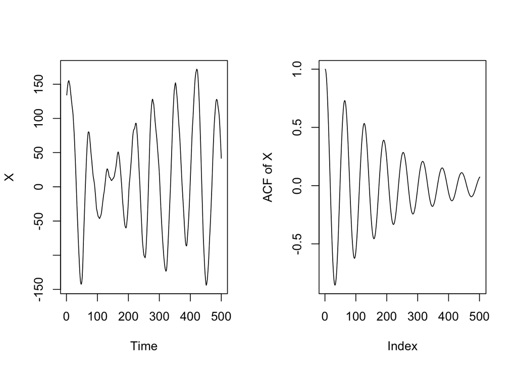

```r
omega <- 0.1
ar_coefs <- c(2/(1+omega^2), - 1/(1+omega^2))
X <- arima.sim(list(ar=ar_coefs),n=500,sd=1)
par(mfrow=c(1,2))
plot(X)
# ARMAacf compute theoretical ACF for an ARMA process
plot(ARMAacf(ar=ar_coefs,lag.max=500),type="l",ylab="ACF of X")
```

Quasi-periodic fluctuations are said to be **phase locked** as long as the random peturbations are not able to knock the oscillations away from being close to their initial phase.

Eventually, the randomness should mean that the process is equally likely to have any phase, regardless of the initial phase.